# Within-chromosome gene-order scrambling (mesosynteny) across Mortierellales, Umbelopsidales and Mucorales

2026-10-27

# 1 Summary

**Question.** CENP-A was lost in the ancestor of Umbelopsidales + Mucorales and CENP-C in the ancestor of Mucorales. Is within-chromosome gene order scrambled faster, for a given sequence divergence, in these clades than in Mortierellales, which keep both proteins?

**Answer.**

- **Mucorales: yes.** Gene order and gene orientation within chromosomes decay much faster per unit of sequence divergence than in Mortierellales (primary test, strand randomisation index: one-sided p < 0.001; Kendall’s tau index p < 0.001). Among closely related pairs (0.01 < d ≤ 0.15 CDS subs/site), the median strand index is 0.32 in Mucorales versus 0.9 in Mortierellales (model-free test p = 0.004).
- **The excess is within chromosomes.** The rate at which neighbouring genes move to *different* chromosomes does not differ between Mucorales and Mortierellales (p = 0.372). Gene content of chromosomes is kept while order and orientation are lost: the mesosynteny pattern of Hane et al. (2011).
- **Umbelopsidales: no.** Umbelopsidales (CENP-A lost, CENP-C kept) scramble no faster than Mortierellales on any index (strand index p = 0.744) and slower than Mucorales (p = 0.006).
- **Interpretation.** Accelerated scrambling coincides with the loss of CENP-C (and the mosaic centromeres described in *Mucor*), not with the loss of CENP-A alone. This is one evolutionary contrast: other Mucorales-specific traits could explain it as well (Section Caveats).
- The preliminary figure’s comparison (*M. fragilis* vs *M. plumbeus* at d = 0.050 vs *M. zonata* vs *L. hyalina* at 0.056) used an older tree. In the current CDS tree the *Mucor* pair is 0.318 subs/site apart. The conclusion still holds with properly matched pairs: *M. circinelloides* strains (d = 0.026) and *M. fragilis* strains (d = 0.071) are already scrambled, unlike *M. zonata* vs *L. hyalina* (d = 0.040).

Logs: DECISIONS.md (all analysis decisions, including those made after looking at data) and LITERATURE.md (searches and sources).

# 2 Background

*Mucor circinelloides* lacks CENP-A and CENP-C and has “mosaic” centromeres: a short kinetochore-binding core flanked by Grem-LINE1 retroelements (Navarro-Mendoza et al. 2019). Both proteins are absent across Mucorales; CENP-A is also absent in Umbelopsidales (this project). Losing these proteins should change centromere organisation, and centromeres constrain which rearrangements are viable (pericentric inversions, translocations between centromeres; Coelho et al. 2024, Guin et al. 2020).

*Mesosynteny* (Hane et al. 2011) is conservation of gene content within homologous chromosomes with randomised gene order and orientation. It was described in filamentous Ascomycetes, especially Dothideomycetes, and attributed to frequent intrachromosomal inversions with rare translocations. Similar patterns, conserved chromosome content with scrambled order, are known from holocentric lineages that lost CenH3/CENP-A: Lepidoptera (d’Alençon et al. 2010) and rhabditid nematodes (Coghlan & Wolfe 2002; Gonzalez de la Rosa et al. 2021). They also occur in monocentric lineages (*Drosophila* Muller elements, Bhutkar et al. 2008; *Oikopleura*, Plessy et al. 2024), so the pattern alone is not diagnostic of centromere change. No published study was found that relates kinetochore gene loss in fungi to the rate of within-chromosome scrambling.

# 3 Data

- **Genomes:** 60 Mucoromycota genomes with gene coordinates (13 Mortierellales, 6 Umbelopsidales, 41 Mucorales). *Mucor lusitanicus* (MucCirc3) is excluded because its OrthoFinder protein IDs cannot be linked to its coordinate table (DECISIONS.md D3).
- **Orthologues:** OrthoFinder 2.5.4 pairwise orthologues (`data/orthofinder/results/Orthologues`); one-to-one orthologues are used as anchors. No Mucoromycota GENESPACE run exists in `Mucor/data` on NeLS (D1).
- **Divergence:** patristic distance on the CDS maximum-likelihood tree (substitutions/site; primary); protein distance (OrthoFinder species tree) and time (dated tree) as sensitivity analyses.
- **Pairs:** all 913 within-order pairs (plus EBP-Nor pairs across orders, not used in the tests). Median 5,758 one-to-one anchors per pair (range 2,129–10,731).

Genome QC. Gene N50: number of genes on the sequence at which half of all genes are reached in sequences sorted by gene count.

| Genome | Species | Order | Source | Genes | Sequences with genes | Gene N50 | Genes on seqs >=100 genes | OrthoFinder IDs mapped |
| --- | --- | --- | --- | --- | --- | --- | --- | --- |
| EntParv | Entomortierella parvispora | Mortierellales | Other | 11314 | 38 | 834 | 98.4% | 100.0% |
| EntParv2 | Entomortierella parvispora | Mortierellales | Other | 11897 | 19 | 854 | 98.8% | 100.0% |
| LinAmoe | Linnemannia amoeboidea | Mortierellales | Other | 10875 | 21 | 735 | 99.9% | 100.0% |
| LinElon | Linnemannia elongata | Mortierellales | Other | 14497 | 78 | 575 | 95.2% | 100.0% |
| LinHyal2 | Linnemannia hyalina | Mortierellales | Other | 13010 | 50 | 555 | 97.0% | 100.0% |
| LinSchm | Linnemannia schmuckeri | Mortierellales | Other | 12809 | 25 | 731 | 99.6% | 100.0% |
| MorAlpi2 | Mortierella alpina | Mortierellales | Other | 10844 | 28 | 730 | 97.9% | 100.0% |
| MorAlpi3 | Mortierella alpina | Mortierellales | Other | 10704 | 32 | 671 | 97.5% | 100.0% |
| ggMorZona1 | Mortierella zonata | Mortierellales | EBPNOR | 12935 | 34 | 709 | 98.8% | 100.0% |
| gzDisGlob2 | Dissophora globulifera | Mortierellales | EBPNOR | 10985 | 25 | 1148 | 98.2% | 100.0% |
| gzLinHyal1 | Linnemannia hyalina | Mortierellales | EBPNOR | 13195 | 31 | 735 | 99.0% | 100.0% |
| gzMorAlpi1 | Mortierella alpina | Mortierellales | EBPNOR | 11632 | 21 | 871 | 98.7% | 100.0% |
| gzPodHuml1 | Podila humilis | Mortierellales | EBPNOR | 13808 | 28 | 1045 | 98.7% | 100.0% |
| AbsRepe | Absidia repens | Mucorales | Other | 15151 | 82 | 414 | 92.5% | 100.0% |
| BenPoit | Benjaminiella poitrasii | Mucorales | Other | 11834 | 20 | 1503 | 97.9% | 100.0% |
| CunBert | Cunninghamella bertholletiae | Mucorales | Other | 10120 | 8 | 1571 | 99.6% | 100.0% |
| DicEleg | Dichotomocladium elegans | Mucorales | Other | 12559 | 130 | 362 | 94.7% | 100.0% |
| HalRadi | Halteromyces radiatus | Mucorales | Other | 10305 | 22 | 1448 | 99.0% | 100.0% |
| LicRamo | Lichtheimia ramosa | Mucorales | Other | 11149 | 10 | 1195 | 100.0% | 100.0% |
| MucCirc5 | Mucor circinelloides | Mucorales | Other | 11231 | 32 | 577 | 98.7% | 100.0% |
| MucPiri | Mucor piriformis | Mucorales | Other | 10867 | 7 | 5867 | 99.7% | 100.0% |
| MucVelu | Mucor velutinosus | Mucorales | Other | 13535 | 39 | 844 | 94.6% | 100.0% |
| MycAfri | Mycotypha africana | Mucorales | Other | 11070 | 28 | 839 | 97.3% | 100.0% |
| PhaArti | Phascolomyces articulosus | Mucorales | Other | 14554 | 127 | 319 | 86.7% | 100.0% |
| PhyBlak1 | Phycomyces blakesleeanus | Mucorales | Other | 13146 | 86 | 472 | 93.7% | 100.0% |
| PhyBlak2 | Phycomyces blakesleeanus | Mucorales | Other | 12930 | 70 | 390 | 93.9% | 100.0% |
| RadSpec | Radiomyces spectabilis | Mucorales | Other | 11044 | 32 | 749 | 99.3% | 100.0% |
| RhiMicr2 | Rhizopus microsporus | Mucorales | Other | 10746 | 51 | 757 | 99.4% | 100.0% |
| SynRace | Syncephalastrum racemosum | Mucorales | Other | 11247 | 39 | 1042 | 98.4% | 100.0% |
| ggMucLanc1 | Mucor lanceolatus | Mucorales | EBPNOR | 11303 | 64 | 362 | 90.7% | 100.0% |
| ggRhiOryz1 | Rhizopus oryzae | Mucorales | EBPNOR | 14249 | 22 | 957 | 99.3% | 100.0% |
| gzAbsCyli1 | Absidia cylindrospora | Mucorales | EBPNOR | 15992 | 21 | 2074 | 98.8% | 100.0% |
| gzAbsGlau1 | Absidia glauca | Mucorales | EBPNOR | 13112 | 25 | 731 | 98.0% | 99.0% |
| gzCunBlak1 | Cunninghamella blakesleeana | Mucorales | EBPNOR | 11122 | 22 | 1565 | 97.1% | 100.0% |
| gzCunEchi1 | Cunninghamella echinulata | Mucorales | EBPNOR | 11249 | 20 | 1429 | 97.5% | 100.0% |
| gzLicCory1 | Lichtheimia corymbifera | Mucorales | EBPNOR | 12932 | 14 | 1306 | 99.4% | 98.8% |
| gzMucCirc1 | Mucor circinelloides | Mucorales | EBPNOR | 12460 | 34 | 924 | 96.2% | 100.0% |
| gzMucCirc2 | Mucor circinelloides | Mucorales | EBPNOR | 12101 | 17 | 932 | 99.4% | 100.0% |
| gzMucFlav2 | Mucor flavus | Mucorales | EBPNOR | 11827 | 33 | 864 | 97.6% | 100.0% |
| gzMucFlav3 | Mucor flavus | Mucorales | EBPNOR | 11985 | 20 | 1233 | 96.3% | 100.0% |
| gzMucFlav4 | Mucor flavus | Mucorales | EBPNOR | 13386 | 115 | 947 | 77.7% | 100.0% |
| gzMucFrag1 | Mucor fragilis | Mucorales | EBPNOR | 11908 | 21 | 1143 | 98.1% | 100.0% |
| gzMucFrag2 | Mucor fragilis | Mucorales | EBPNOR | 11364 | 20 | 1277 | 97.6% | 100.0% |
| gzMucFrag3 | Mucor fragilis | Mucorales | EBPNOR | 11584 | 22 | 1063 | 97.9% | 100.0% |
| gzMucHiem1 | Mucor hiemalis | Mucorales | EBPNOR | 12726 | 16 | 1464 | 98.7% | 100.0% |
| gzMucPlum1 | Mucor plumbeus | Mucorales | EBPNOR | 11113 | 31 | 583 | 96.6% | 100.0% |
| gzMucPlum2 | Mucor plumbeus | Mucorales | EBPNOR | 11786 | 19 | 1299 | 98.3% | 100.0% |
| gzMucPlum3 | Mucor plumbeus | Mucorales | EBPNOR | 11519 | 20 | 1200 | 97.2% | 100.0% |
| gzMucPlum4 | Mucor plumbeus | Mucorales | EBPNOR | 11569 | 21 | 1042 | 98.4% | 100.0% |
| gzMucPlum5 | Mucor plumbeus | Mucorales | EBPNOR | 11599 | 26 | 1253 | 96.3% | 100.0% |
| gzMucPlum6 | Mucor plumbeus | Mucorales | EBPNOR | 11368 | 18 | 1180 | 97.5% | 100.0% |
| gzMucPlum7 | Mucor plumbeus | Mucorales | EBPNOR | 11721 | 29 | 1060 | 97.4% | 100.0% |
| gzRhiMicr1 | Rhizopus microsporus | Mucorales | EBPNOR | 10755 | 19 | 1774 | 98.0% | 100.0% |
| gzRhiStol1 | Rhizopus stolonifer | Mucorales | EBPNOR | 13219 | 20 | 1064 | 98.7% | 100.0% |
| UmbIsab2 | Umbelopsis isabellina | Umbelopsidales | Other | 9033 | 25 | 545 | 98.7% | 100.0% |
| UmbVina3 | Umbelopsis vinacea | Umbelopsidales | Other | 9240 | 35 | 531 | 94.2% | 100.0% |
| gzUmbIsab1 | Umbelopsis isabellina | Umbelopsidales | EBPNOR | 9569 | 23 | 716 | 97.9% | 100.0% |
| gzUmbRama1 | Umbelopsis ramanniana | Umbelopsidales | EBPNOR | 9709 | 22 | 661 | 99.0% | 100.0% |
| gzUmbVina1 | Umbelopsis vinacea | Umbelopsidales | EBPNOR | 9942 | 22 | 686 | 97.8% | 100.0% |
| gzUmbVina2 | Umbelopsis vinacea | Umbelopsidales | EBPNOR | 8439 | 20 | 569 | 98.4% | 100.0% |

# 4 Methods

**Anchors.** For each genome pair, one-to-one orthologues from the OrthoFinder pairwise tables are placed on the assemblies. Gene order is the rank of an anchor among anchors on the same sequence. Relative orientation is +1 if both genes are on the same strand.

**Indices** (re-implementations for orthologue anchors of published indices; checked on synthetic genomes in `R/test_functions.R`). Each index is computed with each genome as reference and the two values are averaged.

| Scale | Index | Definition | Source |
| --- | --- | --- | --- |
| macro | Neighbour on same chromosome | fraction of adjacent anchors whose orthologues are on the same chromosome in the other genome | breakpoint logic of Plessy et al. 2024 |
| macro | Synteny index; macrosynteny fraction | anchors on the best-matching chromosome; anchors on Fisher-significant chromosome pairs | GenomicBreaks; odp, macrosyntR |
| meso | **Strand randomisation index** (primary) | per chromosome and its best-matching partner, `\|n_same - n_opposite\| / n`, anchor-weighted mean | GenomicBreaks, Plessy et al. 2024 |
| meso | Kendall’s tau index; correlation index | `\|tau\|` of anchor ranks; `\|r\|` of positions, on the same chromosome pairs | GenomicBreaks (correlation index) |
| micro | GOC; conserved adjacency | adjacent anchors whose orthologues are within 4 (GOC) or 1 anchor(s) on the other chromosome | Rocha 2003; GenomicBreaks |

Within-chromosome indices are normalised to `(observed - random) / (1 - random)` using 20 shuffles of anchor positions within each chromosome (chromosome content kept, orientation randomised): 1 = conserved, 0 = as random as chromosome content allows. The “same chromosome” index is not normalised.

**Decay with divergence.** Each index is modelled as `I(d) = c * exp(-(lambda * d)^beta)`. The ceiling `c` comes from 14 near-identical pairs (d ≤ 0.01); `beta` (shape) is shared by all clades and estimated per index; `lambda` is the clade-specific rate. Each pair with 0.01 < d ≤ 0.65 gets a rate `lambda_ij = (-log(I_ij / c))^(1/beta) / d_ij`. The range ends just above the deepest split within Mortierellales and Umbelopsidales, so all clades are compared over the same range. The model and its shared shape were set after an interim look at the data (DECISIONS.md D11-D12). The plain exponential model (`beta = 1`) that was specified first is reported as a sensitivity analysis.

**Tests.** Pairs share branches, so tests use sets of phylogenetically independent pairs (paths in the ML tree share no branch; Maddison 2000), chosen greedily with the shortest paths first and random tie-breaks. Each of 1000 draws contains up to 6 Mortierellales, 3 Umbelopsidales and 12 Mucorales pairs. In each draw, one-sided Wilcoxon rank-sum tests compare per-pair rates between clades. Reported values are the median p over draws and the fraction of draws with p < 0.05. A model-free test compares raw index values of independent pairs with 0.01 < d ≤ 0.15.

**Pre-specified primary test:** strand randomisation index, CDS distance, all genomes, Mucorales > Mortierellales and Umbelopsidales > Mortierellales. The primary index was chosen after a six-pair pilot, before any clade comparison (D7).

# 5 Results

## 5.1 Dot plots at matched divergence

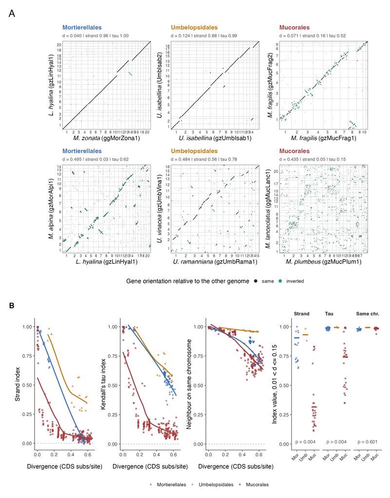

**Figure 1.** (A) Oxford dot plots of one-to-one orthologues for pairs at similar divergence within each order: top row closely related, bottom row d ≈ 0.45. Points are coloured by gene orientation relative to the other genome, after orienting each chromosome on its main diagonal. Grid lines are sequence boundaries (sequences with ≥ 1.5% of anchors; numbered by size). (B) Indices against CDS divergence for all within-order pairs with d ≤ 0.65, with descriptive LOESS smoothers. Right panel: index values at matched divergence (0.01 < d ≤ 0.15); points are all pairs in this range. Pairs whose paths in the tree share a branch are not independent (a rearrangement on that branch counts in each of them), so bars and p use only sets of phylogenetically independent pairs, whose paths share no branch (Maddison 2000). 1,000 such sets were drawn, each with 4 Mortierellales, 2 Umbelopsidales and 8 Mucorales pairs. A bar is the median over draws of the clade’s median index value; p is the median over draws of a one-sided Wilcoxon test that Mucorales pairs are more scrambled than Mortierellales pairs.

Mortierellales and Umbelopsidales keep long collinear diagonals between closely related genomes (Figure 1A, top). In Mucorales, pairs of similar or smaller divergence already show the mesosyntenic pattern: genes stay on the homologous chromosome, but order is broken into short, often inverted segments. At d ≈ 0.45, Mortierellales and Umbelopsidales still show recognisable diagonals made of rearranged blocks. *M. plumbeus* vs *M. lanceolatus* shows only clouds of dots within chromosome-pair boxes.

More closely related pairs are in Supplementary Figure S1: within-species *Mucor* strain pairs at d = 0.02-0.06 are already strongly rearranged.

## 5.2 Decay rates and tests

One-sided tests on phylogenetically independent pairs (median p over draws). ‘Rates’: per-pair decay rates, CDS distance, all genomes. ‘Matched’: raw index values of pairs with 0.01 < d <= 0.15. With 3 Umbelopsidales pairs (2 in the matched window), the smallest attainable p for comparisons with Umbelopsidales is about 0.006 (0.025).

| Scale | Index | Comparison | p (rates) | draws p<0.05 | p (matched d<=0.15) |
| --- | --- | --- | --- | --- | --- |
| meso | Strand randomisation index | Mucorales > Mortierellales | < 0.001 | 100% | 0.004 |
| meso | Strand randomisation index | Mucorales > Umbelopsidales | 0.006 | 100% | 0.025 |
| meso | Strand randomisation index | Umbelopsidales > Mortierellales | 0.744 | 0% | 0.756 |
| meso | Kendall’s tau index | Mucorales > Mortierellales | < 0.001 | 100% | 0.004 |
| meso | Kendall’s tau index | Mucorales > Umbelopsidales | 0.013 | 100% | 0.025 |
| meso | Kendall’s tau index | Umbelopsidales > Mortierellales | 0.552 | 0% | 0.756 |
| meso | Correlation index | Mucorales > Mortierellales | 0.001 | 100% | 0.004 |
| meso | Correlation index | Mucorales > Umbelopsidales | 0.018 | 100% | 0.025 |
| meso | Correlation index | Umbelopsidales > Mortierellales | 0.664 | 0% | 0.756 |
| micro | GOC (vicinity 4) | Mucorales > Mortierellales | 0.008 | 100% | 0.007 |
| micro | GOC (vicinity 4) | Mucorales > Umbelopsidales | 0.006 | 100% | 0.025 |
| micro | GOC (vicinity 4) | Umbelopsidales > Mortierellales | 0.940 | 0% | 0.876 |
| micro | Conserved adjacency | Mucorales > Mortierellales | 0.011 | 100% | 0.025 |
| micro | Conserved adjacency | Mucorales > Umbelopsidales | 0.006 | 100% | 0.025 |
| micro | Conserved adjacency | Umbelopsidales > Mortierellales | 0.965 | 0% | 0.876 |
| macro | Neighbour on same chromosome | Mucorales > Mortierellales | 0.372 | 0% | 0.601 |
| macro | Neighbour on same chromosome | Mucorales > Umbelopsidales | 0.006 | 100% | 0.075 |
| macro | Neighbour on same chromosome | Umbelopsidales > Mortierellales | 0.953 | 0% | 0.876 |

Decay rate lambda per CDS substitution/site: median of per-clade median rates over independent-pair draws (95% range over draws). Higher = faster loss of order.

| Index | Mortierellales | Umbelopsidales | Mucorales | shape beta |
| --- | --- | --- | --- | --- |
| Strand randomisation index | 1.74 (1.6-1.74) | 1.37 (1.37-1.37) | 8.72 (7.77-8.72) | 1.43 |
| Kendall’s tau index | 0.0515 (0.0436-0.0515) | 0.0252 (0.0252-0.0252) | 5.08 (4.32-5.08) | 0.85 |
| Correlation index | 0.00672 (0.00664-0.00672) | 0 (0-0) | 3.39 (3.25-3.42) | 0.82 |
| GOC (vicinity 4) | 0.1 (0.1-0.1) | 0.0226 (0.0226-0.0226) | 0.498 (0.472-0.498) | 1.01 |
| Conserved adjacency | 0.15 (0.15-0.15) | 0.0067 (0.0067-0.0067) | 0.699 (0.666-0.699) | 0.99 |
| Neighbour on same chromosome | 1.22 (1.22-1.3) | 0.258 (0.258-0.258) | 1.4 (1.4-1.43) | 2.02 |

Index values among closely related pairs (0.01 < d <= 0.15): median over independent-pair draws (independent pairs per draw).

| Index | Mortierellales | Umbelopsidales | Mucorales |
| --- | --- | --- | --- |
| Strand randomisation index | 0.90 (n = 4) | 0.93 (n = 2) | 0.32 (n = 8) |
| Kendall’s tau index | 0.99 (n = 4) | 0.99 (n = 2) | 0.74 (n = 8) |
| Correlation index | 0.99 (n = 4) | 1.00 (n = 2) | 0.85 (n = 8) |
| GOC (vicinity 4) | 0.99 (n = 4) | 1.00 (n = 2) | 0.98 (n = 8) |
| Conserved adjacency | 0.98 (n = 4) | 0.99 (n = 2) | 0.96 (n = 8) |
| Neighbour on same chromosome | 0.98 (n = 4) | 0.99 (n = 2) | 0.98 (n = 8) |

Among all pairs in the matched window, the Mucorales pairs are, if anything, *less* divergent (median d = 0.063) than the Mortierellales pairs (median d = 0.105), which makes the comparison conservative.

**Scale of the difference.** Mucorales lose order at the meso scale (strand orientation, chromosome-wide rank correlation) many times faster than Mortierellales. Among closely related pairs, local neighbourhoods (GOC, adjacency) also break faster in Mucorales, but the absolute difference is small (GOC 0.98 vs 0.99): most genes keep their immediate neighbours, so Mucorales rearrangements move and invert blocks of several genes rather than single genes. At d ≈ 0.5, Mortierellales have lost as many or more local adjacencies than Mucorales (Supplementary Figure S2), so the micro-scale difference is limited to recent divergence. Inter-chromosomal exchange (neighbour on the same chromosome) does not differ between Mucorales and Mortierellales.

**Mortierellales also randomise gene orientation, but more slowly and without losing global order.** At d ≈ 0.4-0.6 the strand index of Mortierellales pairs approaches 0, while Kendall’s tau stays around 0.5 (Figure 1B, Supplementary Figure S3). This fits many small inversions that flip genes locally while the chromosome-scale diagonal is kept. Mucorales lose both.

**Umbelopsidales** keep order at least as well as Mortierellales on every index. Only 6 genomes and 3 independent pairs are available, so a modest acceleration cannot be excluded, but the point estimates go in the opposite direction.

## 5.3 Sensitivity analyses

Median one-sided p across sensitivity settings. EBP-Nor only: 2 Mortierellales and 1-2 Umbelopsidales independent pairs per draw, so power is low.

| setting | Index | Mucorales > Mortierellales | Mucorales > Umbelopsidales | Umbelopsidales > Mortierellales |
| --- | --- | --- | --- | --- |
| 1 Primary (all genomes, CDS, stretched) | Kendall’s tau index | < 0.001 | 0.013 | 0.552 |
| 1 Primary (all genomes, CDS, stretched) | Neighbour on same chromosome | 0.372 | 0.006 | 0.953 |
| 1 Primary (all genomes, CDS, stretched) | Strand randomisation index | < 0.001 | 0.006 | 0.744 |
| 2 Protein distance | Kendall’s tau index | 0.001 | 0.018 | 0.552 |
| 2 Protein distance | Neighbour on same chromosome | 0.519 | 0.009 | 0.953 |
| 2 Protein distance | Strand randomisation index | < 0.001 | 0.006 | 0.653 |
| 3 Time (dated tree) | Kendall’s tau index | < 0.001 | 0.013 | 0.552 |
| 3 Time (dated tree) | Neighbour on same chromosome | 0.407 | 0.006 | 0.953 |
| 3 Time (dated tree) | Strand randomisation index | < 0.001 | 0.006 | 0.744 |
| 4 Exponential model (beta = 1) | Kendall’s tau index | < 0.001 | 0.009 | 0.552 |
| 4 Exponential model (beta = 1) | Neighbour on same chromosome | 0.213 | 0.018 | 0.953 |
| 4 Exponential model (beta = 1) | Strand randomisation index | < 0.001 | 0.006 | 0.552 |
| 5 EBP-Nor genomes only | Kendall’s tau index | 0.025 | 0.025 | 0.349 |
| 5 EBP-Nor genomes only | Neighbour on same chromosome | 0.348 | 0.025 | 0.974 |
| 5 EBP-Nor genomes only | Strand randomisation index | 0.120 | 0.025 | 0.651 |

Conclusions are unchanged with protein distance, time, or the plain exponential model. With EBP-Nor genomes only (one annotation pipeline), the Mucorales vs Mortierellales difference remains for Kendall’s tau and the correlation index but not for the strand index. This set has only two independent Mortierellales pairs.

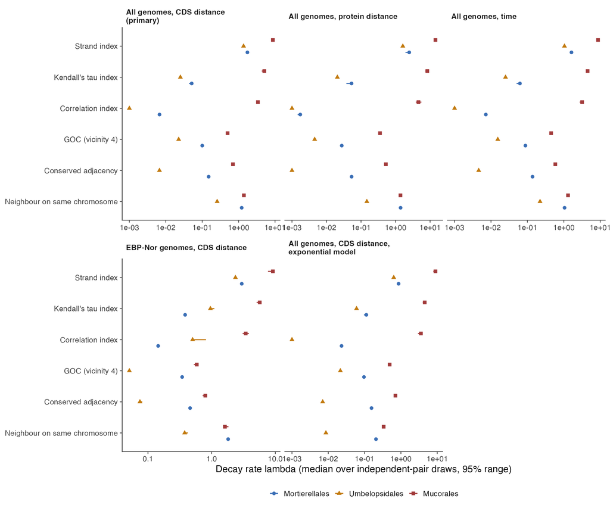

**Supplementary Figure S4.** Decay rates per clade for all indices and sensitivity settings (median over independent-pair draws, 95% range). Rates of 0 are drawn at 0.001.

# 6 Caveats

1. **One evolutionary contrast.** CENP-C was lost once, on the stem of Mucorales. Anything else that changed on that branch could explain the faster scrambling just as well: whole-genome duplication in Mucorales, Grem-LINE retroelements at centromeres, RNAi/heterochromatin pathways, genome and repeat content, life history, frequency of sex. The data show a coincidence in timing, not a mechanism. The Umbelopsidales result is informative because it separates CENP-A loss from CENP-C loss, but it is based on 6 genomes.
2. **Mesosynteny is not specific to centromere change.** Dothideomycetes (monocentric, CENP-A present) show the same pattern (Hane et al. 2011).
3. **The strand index has a block-size-dependent floor.** If genes move in blocks that keep their internal orientation, the expected index under complete scrambling is above the gene-level random expectation used for normalisation. Mucorales pairs level off at ~0.05-0.15 rather than 0 (Figure 1B). This affects deep pairs only. The tests rely on shallow pairs, and the tau and correlation indices give the same conclusion.
4. **Rate model.** The stretched-exponential shape was chosen after an interim look at the data (D11-D12). With one shape shared by all clades it fits poorly in places (Supplementary Figure S5): the Mucorales strand index at intermediate divergence and Mortierellales tau/correlation among close pairs. Decay is therefore not well described by a single rate per clade, and the rate values should be read as summaries, not as estimates of a rearrangement rate. The model-free matched-divergence test and the plain exponential model give the same conclusions.
5. **Assemblies and annotation.** Public and EBP-Nor genomes differ in annotation pipeline. All genomes are highly contiguous (≥ 78% of genes on sequences with ≥ 100 genes). Indices are computed per homologous sequence pair, so fragmentation reduces anchors rather than adding apparent scrambling. Misassemblies would show up as isolated off-diagonal blocks, not as the within-box scatter seen in Mucorales.
6. **Pairs selected for maximal independence** favour closely related pairs (D13). Rates are normalised by divergence, and the matched-divergence test does not rely on the rate model.

# 7 Possible next steps

- Map centromeres (Hi-C contact maps are on NeLS under `data/HiC/mcool`; AT-rich, Grem-LINE-associated regions in Mucorales). Then test whether rearrangement breakpoints are enriched near centromeres and whether centromere positions are conserved within chromosome-pair boxes.
- Count inversions directly (breakpoint graphs, e.g. GenomicBreaks) to estimate inversion size distributions per clade. The data here suggest small inversions in Mortierellales and larger, more frequent ones in Mucorales.
- Add Umbelopsidales genomes, or more closely related Umbelopsidales pairs, to raise power for the CENP-A-only contrast.

# 8 Supplementary figures

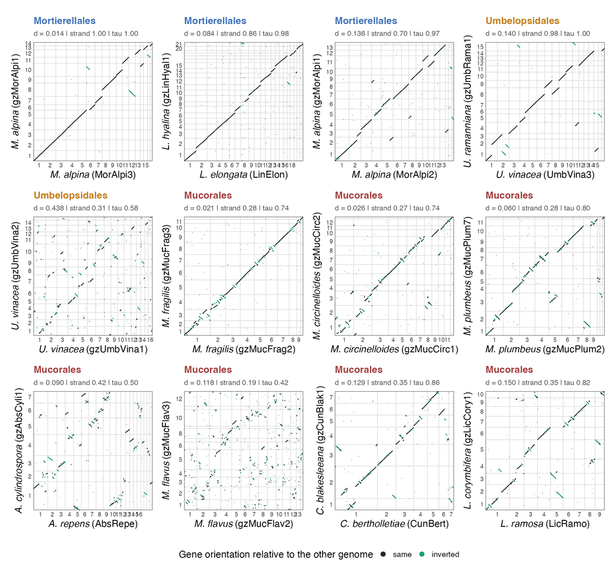

**Supplementary Figure S1.** Oxford dot plots for additional closely related pairs (sorted by order and divergence).

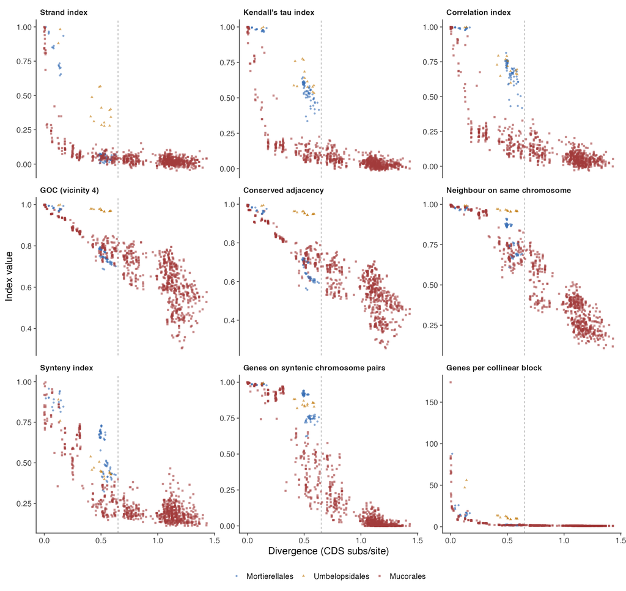

**Supplementary Figure S2.** All indices against CDS divergence for all within-order pairs (full divergence range; dashed line: upper limit of the range used for tests).

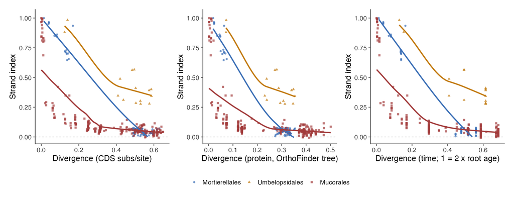

**Supplementary Figure S3.** Strand randomisation index against the three divergence measures.

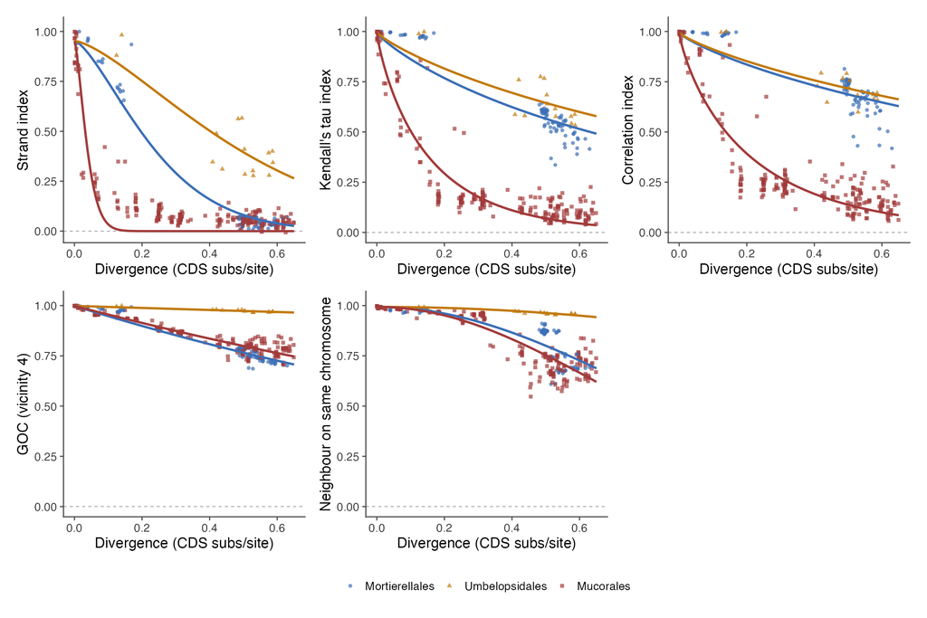

**Supplementary Figure S5.** Stretched-exponential fits (clade-specific rate, shared shape) used for per-pair rates.

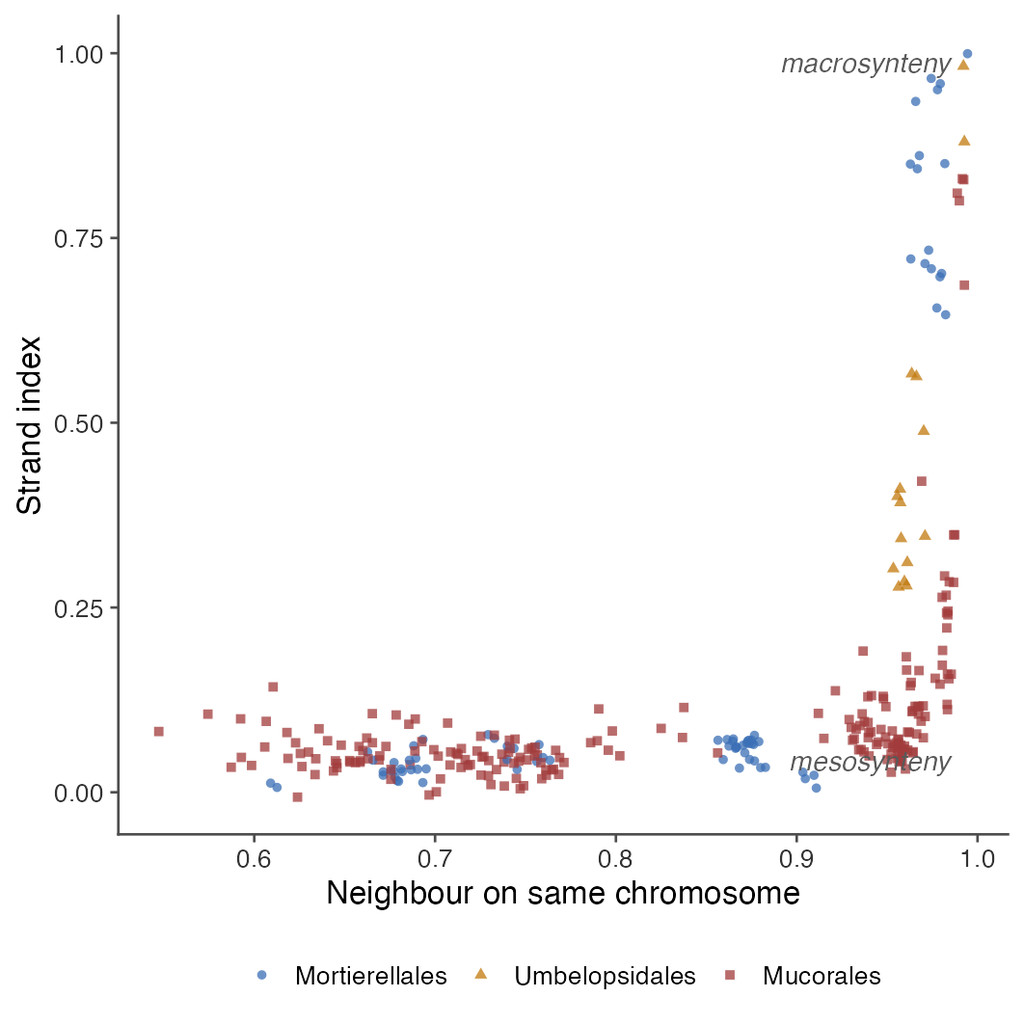

**Supplementary Figure S6.** Chromosome membership (neighbour on same chromosome) against within-chromosome orientation (strand index) per pair (0.01 < d <= 0.65). Mucorales pairs fill the mesosyntenic corner: high chromosome conservation, low order conservation.

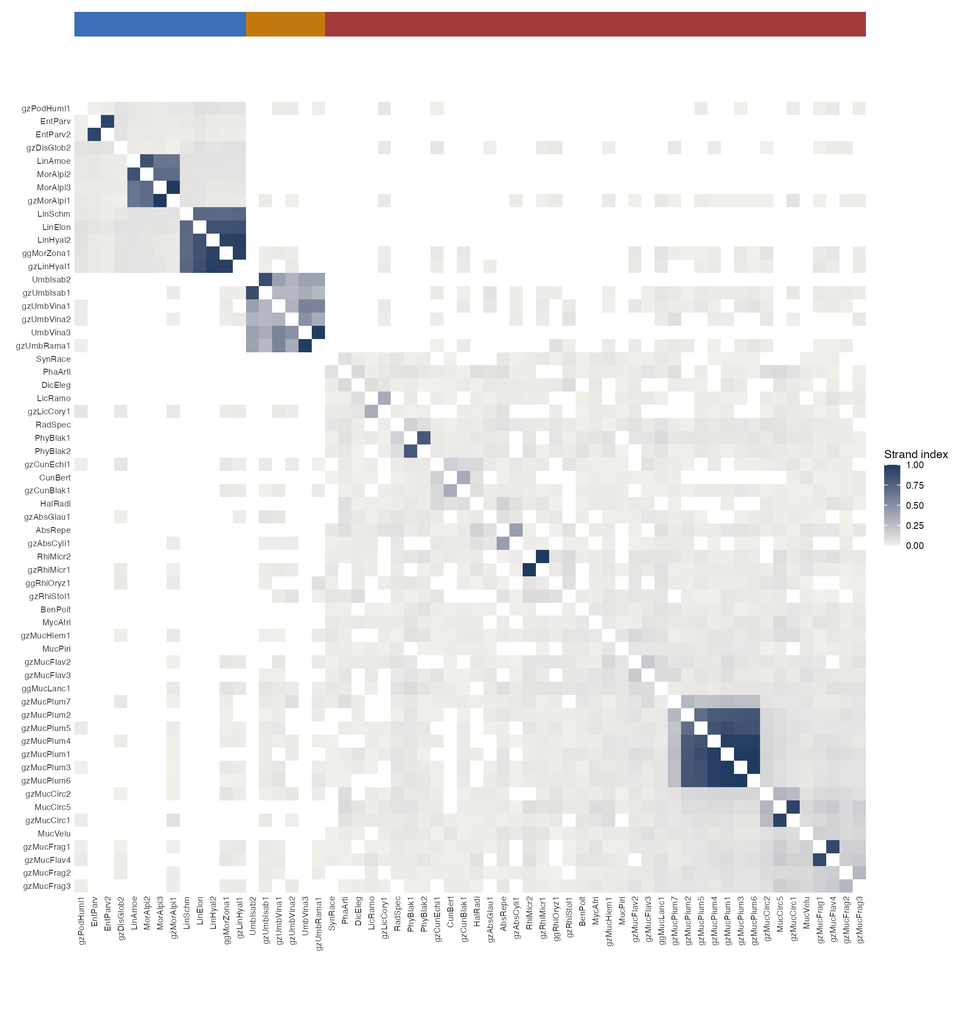

**Supplementary Figure S7.** Strand randomisation index for all analysed pairs; genomes in phylogenetic order (top bar: order). White: pair not analysed (public genomes from different orders).

# 9 Reproducibility

```bash
bash analysis/synteny/run_all.sh
```

Outputs: `analysis/synteny/results/tables/*.tsv`, `analysis/synteny/results/figures/*.{pdf,png}`.